# Problem Set 08

Isaac Allen

Last compiled: November 02, 2020

[figure not shown]

# 1 Background

In this problem set we will use a small **sample** of data from the [General Social Survey](http://gss.norc.org/). The survey is designed to monitor changes in both social characteristics and attitudes. You will work with a **sample** from one neighborhood. The full neighborhood of **ALL individuals** is the population. For this problem set we do **not** know the **true population parameters** for any of the variables, because we do not have data on every person in the neighborhood.

## Setup

First load the necessary packages:

```r
# Recall that loading the tidyverse "umbrella" package loads ggplot2, dplyr, and
# readr all at once. Feel free to load these packages any way you choose.
library(tidyverse)
library(moderndive)
```

Next, load the data set from where it is stored on the web:

```r
gss_sample <- read_csv("https://docs.google.com/spreadsheets/d/e/2PACX-1vSypSoDCMH2N76Vo2dZRPkw2q3t1mbvAXlOtgPDIsHg4NclAQFmER-BdvXH9_lrT40UQCVdPXOi_NMJ/pub?gid=257689625&single=true&output=csv")
```

Be sure to take a look at the data in the **viewer**. Each row in the data set is a person that was surveyed (100 rows or cases in total). The variables in the data set include each respondent’s `age`, `race`, and number of hours of TV watched a day `tvhours`.

**Setting a seed:** We will take some random samples and build sampling distributions in this lab. In order to make sure R takes the same random sample every time you run your code, you can do what is called “setting a seed”. Do this in any code chunk that you take a random sample!

You can set a seed like so. Any number will do. (You do not need to run this right now…just showing you how)

```r
set.seed(45)
```

# 2 Confidence Intervals from a Bootstrap Resample

## Step 1: Take 1000 Bootstrap Resamples

The following code tells R to take 1000 bootstrap resamples from the `gss_sample` data. You can set the seed to whatever value you like!

```r
set.seed(42)
boot_samp_1000 <- gss_sample %>%
  rep_sample_n(size = 100, reps = 1000, replace = TRUE)
```

Note a few important details about the `rep_sample_n` function, and bootstrap sampling in general:

- `size = 100` tells R that each bootstrap resample we take has 100 cases… the size of the original sample
- `reps = 1000` tells R to take 1000 bootstrap resamples (each of size 100).
- The `replace = TRUE` argument tells R that in each bootstrap resample, we can include a row from `gss_sample` multiple times. So if for instance, respondent # 12 is the first random resample taken here, respondent 12 is still available to be resampled **again** at random. Thus, some people may appear **multiple times** in our bootstrap resample, and some people from the original data set may not appear at all.
- We save the results in a data frame `boot_samp_1000`.

Take a look at the `boot_samp_1000` data frame we just generated in RStudio’s data viewer. Note that the `replicate` column labels each bootstrap resample (the first 100 rows are labeled 1, the next 100 rows are labeled 2, etc.)

1. How many rows does `boot_samp_1000` have? **Why?**

There are 100,000 rows in `boot_samp_1000` because there are 1000 replicates at size 100 (i.e. 1000 replicates * size 100 = 100,000 rows).

## Step 2: Calculate the Bootstrap Statistic

Let’s say we want to use the bootstrap resample that we just generated to calculate a confidence interval for the population mean $\mu_{tv}$ of `tvhours`. To do so, we need to know the sample mean $\bar{x}$ of `tvhours` **for each of the 1000 bootstrap resamples**. In this case, the sample mean $\bar{x}$ of `tvhours` for **each bootstrap resample** is our **BOOTSTRAP STATISTIC**. We can calculate that with three lines of code as follows:

```r
boot_distrib_tv <- boot_samp_1000 %>%
  group_by(replicate) %>%
  summarize(boot_stat = mean(tvhours))
# or using infer
library(infer)
boot_dist_tv_infer <- gss_sample %>%
  specify(response = tvhours) %>%
  generate(reps = 1000, type = "bootstrap") %>%
  calculate(stat = "mean")
```

Note that:

- The `group_by()` argument tells R to take the sample mean of `tvhours` **separately** for each different `replicate` in the bootstrap resample.
- We put the sample mean for each bootstrap resample in a column called `boot_stat`

> This is the bootstrap distribution for the mean of `tvhours`!

Take a look at the `boot_distrib_tv` we just created in RStudio’s data viewer.

2. How many values of the bootstrap statistic `boot_stat` are there? Please explain **why** there are this many values of the bootstrap statistic.

There are 1,000 values of `boot_stat` because each one represents the sample mean of `tvhours` per replicate in `boot_samp_1000`(i.e. 100 entries in each replicate of `tvhours` added together and divided by 100, done for each replicate (1000)).

## Visualizing the Bootstrap Distribution

The bootstrap distribution is shown in Figure 2.1 . This is a histogram of the `boot_stat` values from `boot_distrib_tv`.

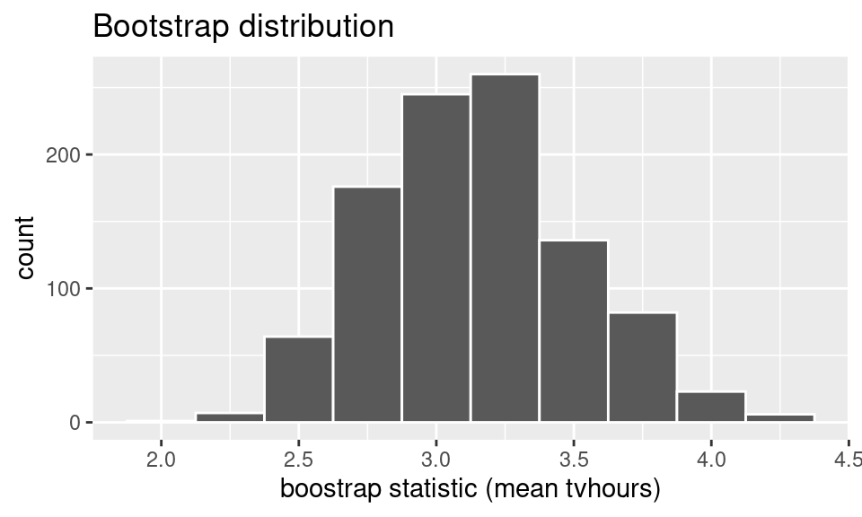

Figure 2.1: Bootstrap distribution of mean TV hours

```r
ggplot(data = boot_distrib_tv, aes(x = boot_stat)) +
  geom_histogram(color = "white", binwidth = 0.25) +
  labs(title = "Bootstrap distribution",
       x = "boostrap statistic (mean tvhours)")
```

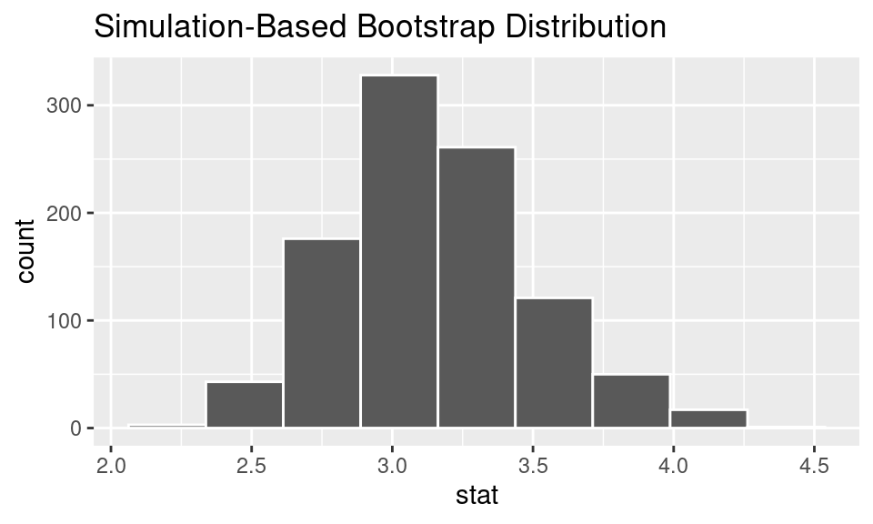

Figure 2.2: Bootstrap distribution computed with `visualize()`

```r
# Or using the infer pipeline
visualize(boot_dist_tv_infer, bins = 9)
```

## Step 3: CI from a Bootstrap Resample

### CI Using the 95% Rule

We can now use the bootstrap distribution for the sample mean `tvhours` $\bar{x}$ to calculate a 95% confidence interval for the population mean `tvhours` $\mu_{tv}$, using the “95% rule for bell shaped distributions”, which states that the middle 95% of values of a bell/normal shaped distribution are between

$$\text{mean} \pm 1.96 \cdot SD$$

- the mean here would be the mean of the bootstrap distribution
- the SD here is the standard deviation of the bootstrap distribution, which recall has a special name: the **standard error**.

We can thus apply the 95% rule, like so:

```r
# Note that z_{0.975} = 1.96
qnorm(0.975)
```

```
[1] 1.959964
```

```r
boot_distrib_tv %>%
  summarize(mean = mean(boot_stat),
            se = sd(boot_stat),
            lower_ci = mean - (qnorm(0.975) * se),
            upper_ci = mean + (qnorm(0.975) * se)) -> bnci_tv
bnci_tv
```

| mean | se | lower_ci | upper_ci |
| --- | --- | --- | --- |
| 3.14418 | 0.3651603 | 2.428479 | 3.859881 |

```r
# Or using infer
xbar <- boot_dist_tv_infer %>%
  summarize(xbar = mean(stat)) %>%
  pull()
xbar
```

```
[1] 3.1451
```

```r
standard_error_ci <- boot_dist_tv_infer %>%
  get_confidence_interval(type = "se", point_estimate = xbar, level = 0.95)
standard_error_ci
```

| lower_ci | upper_ci |
| --- | --- |
| 2.466912 | 3.823288 |

## CI Using the Percentile Method

You can also calculate a 95% confidence interval using the percentile method. The logic goes like this:

Since our bootstrap resample had 1000 values of `boot_stat`:

- 950 of the `boot_stat` values fall **inside** this 95% confidence interval, i.e. 95%
- 25 values fall **below** it. i.e. the lower 2.5%
- 25 values fall **above** it. i.e. the higher 2.5%

totaling 100%. We can use **the quantiles** of the bootstrap distribution to find these values as follows:

```r
bpci_tv <- boot_distrib_tv %>%
  summarize(lower_ci = quantile(boot_stat, 0.025),
            upper_ci = quantile(boot_stat, 0.975))

bpci_tv
```

| lower_ci | upper_ci |
| --- | --- |
| 2.51 | 3.89 |

```r
# Or using infer
boot_dist_tv_infer %>%
  get_confidence_interval(type = "percentile", level = 0.95)
```

| lower_ci | upper_ci |
| --- | --- |
| 2.51 | 3.93 |

```r
# Which is really just doing the following:
boot_dist_tv_infer %>%
  summarize(lower_ci = quantile(stat, 0.025),
            upper_ci = quantile(stat, 0.975))
```

| lower_ci | upper_ci |
| --- | --- |
| 2.51 | 3.93 |

This method

- Asks R to identify the 0.025 quantile of the bootstrap sample means… this is the value **below** which **2.5% of the values of `boot_stat`** fall (or 25 cases in this example… 25/1000 = 0.025)
- Asks R to identify the 0.975 quantile for the bootstrap sample means… this is the value **above** which the other **2.5% of the values of `boot_stat`** fall (or 25 cases in this example 975/1000 = 0.975)
- The middle 95% of the values fall between these two quantiles

Based on these results, we are 95% confident that the **true mean hours of TV watched $\mu_{tv}$ in the population** is between the upper and lower CI we just calculated.

## Visualizing the Confidence Interval

The bootstrap distribution and the 95% **bootstrap percentile** confidence intervals we just calculated are shown in the figure below. This is a histogram of the `boot_stat` values from `boot_distrib_tv`. The green line is the lower bound of the 95% CI, and the blue line is the upper bound. 950 of the 1000 bootstrap resamples had a mean for `tvhours` that fell **between** the green and blue lines…25 of the samples had a mean above the blue line, and 25 of the samples had a mean below the green line.

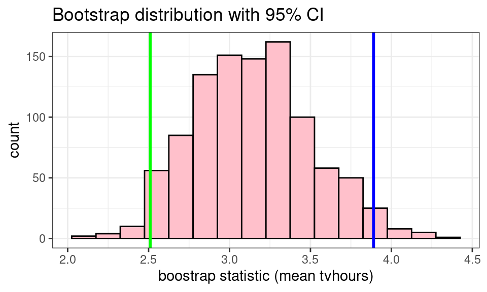

3. **If** we calculated a **90% bootstrap percentile** confidence interval for the mean of `tvhours` using this same bootstrap resample and the percentile method, roughly how many of the 1000 values of `tv_mean` would fall between the `lower_ci` and the `upper_ci`?

There would be 900 values of `tv_mean` falling between the `lower_ci` and the `upper_ci` using a 90% bootstrap percentile confidence interval.

4. Use the bootstrap resampling distribution for `tvhours` generated above (`boot_distrib_tv`) and the **bootstrap percentile** method to calculate a 99% **bootstrap percentile** confidence interval for the mean `tvhours`.

```r
q4 <- boot_distrib_tv %>%
  summarize(lower_ci = quantile(boot_stat, 0.005),
            upper_ci = quantile(boot_stat, 0.995))
q4
```

| lower_ci | upper_ci |
| --- | --- |
| 2.31995 | 4.1302 |

According to `q4` we can be 99% confident that the true mean hours of TV watched $\mu_{tv}$ in the population is between 2.31995 and 4.1302.

5. Which confidence interval is **WIDER**: the 95% confidence interval or the 99% confidence interval for the population mean `tvhours` $\mu_{tv}$? Why?

The 99% confidence interval is wider than the 95% confidence interval because as confidence increases, the number of samples within it also increases and vice versa.

6. Use the bootstrap resample we generated above (`boot_samp_1000`), to generate a **bootstrap distribution** for the sample mean respondent `age` $\bar{x}$ instead of `tvhours`. Please be sure to **name it something different** than the bootstrap distribution for the sample mean of `tvhours`

```r
boot_distrib_age <- boot_samp_1000 %>%
  group_by(replicate) %>%
  summarize(boot_stat = mean(age))
```

7. Calculate a 95% confidence interval for the population mean respondent `age` $\mu_{age}$ using the **95% rule** method.

```r
boot_distrib_age %>%
  summarise(mean = mean(boot_stat),
            se = sd(boot_stat),
            lower_ci = mean - (qnorm(0.975) * se),
            upper_ci = mean + (qnorm(0.975) * se)) -> bnci_age
bnci_age
```

| mean | se | lower_ci | upper_ci |
| --- | --- | --- | --- |
| 47.60143 | 1.673659 | 44.32112 | 50.88174 |

According to `bnci_age` we can be 95% confident that the true mean age of respondents $\mu_{age}$ in the population is approximately between 44.3 and 50.9 years old.

8. Calculate a 95% bootstrap percentile confidence interval for the population mean respondent `age` $\mu_{age}$.

```r
q8 <- boot_distrib_age %>%
  summarize(lower_ci = quantile(boot_stat, 0.025),
            upper_ci = quantile(boot_stat, 0.975))
q8
```

| lower_ci | upper_ci |
| --- | --- |
| 44.47 | 50.97075 |

9. How do the 95% confidence intervals you calculated in 7 and 8 compare? i.e. are the 95% CI values similar or are they pretty different?

The values for each lower and upper bounds calculated in 7 and 8 are nearly symbolic of each other, returning very marginal differences.

10. Use the **bootstrap resampling distribution** for the sample mean respondent `age` and the percentile method to calculate an 80% confidence interval for the population mean respondent age $\mu_{age}$.

```r
q10 <- boot_distrib_age %>%
  summarize(lower_ci = quantile(boot_stat, 0.1),
            upper_ci = quantile(boot_stat, 0.9))

q10
```

| lower_ci | upper_ci |
| --- | --- |
| 45.49 | 49.681 |

According to `q10` we can be 80% confident that the true population mean respondent age $\mu_{age}$ is approximately between 45.5 and 49.7 years old.

[figure not shown]

# 3 Bootstrap Sampling Distribution & Confidence Intervals with Categorical Variables

The procedure for generating a bootstrap sampling distribution is VERY similar for categorical data. As an example we will generate a bootstrap sampling distribution for the proportion of respondents that identified as a Person of Color.

## Step 1: Take 1000 Bootstrap Resamples

We already did this above! We can use the same `boot_samp_1000` as before.

## Step2: Calculate the Bootstrap Statistic $\hat{p}$

```r
boot_distrib_POC <- boot_samp_1000 %>%
  group_by(replicate) %>%
  summarize(n = n(),
            POC_count = sum(race == "POC"),
            boot_stat = POC_count/n,
            phat_boot = mean(race == "POC"))
head(boot_distrib_POC)
```

| replicate | n | POC_count | boot_stat | phat_boot |
| --- | --- | --- | --- | --- |
| 1 | 100 | 26 | 0.26 | 0.26 |
| 2 | 100 | 24 | 0.24 | 0.24 |
| 3 | 100 | 25 | 0.25 | 0.25 |
| 4 | 100 | 16 | 0.16 | 0.16 |
| 5 | 100 | 28 | 0.28 | 0.28 |
| 6 | 100 | 22 | 0.22 | 0.22 |

## Step 3: Generate the 95% Confidence Interval

### CI Using the 95% Rule

The following will calculate the 95% confidence interval for the proportion of people that identified as `POC` using the 95% rule.

```r
boot_distrib_POC %>%
  summarize(mean = mean(boot_stat),
            se = sd(boot_stat),
            lower_ci = mean - (qnorm(0.975) * se),
            upper_ci = mean + (qnorm(0.975) * se))
```

| mean | se | lower_ci | upper_ci |
| --- | --- | --- | --- |
| 0.24053 | 0.0421354 | 0.1579461 | 0.3231139 |

### CI with the Percentile Method

The following will calculate the 95% confidence interval for the proportion of people that identified as “POC” using the percentile method.

```r
boot_distrib_POC %>%
  summarize(lower_ci = quantile(boot_stat, 0.025),
            upper_ci = quantile(boot_stat, 0.975))
```

| lower_ci | upper_ci |
| --- | --- |
| 0.16 | 0.33 |

11. Calculate a 95% CI for the **population proportion** of respondents $p$ who identified as **White** using EITHER the percentile or 95% rule method. Note that you will first need to generate the bootstrap distribution for the proportion of respondents who identified as `White`.

```r
boot_distrib_White <- boot_samp_1000 %>%
  group_by(replicate) %>%
  summarize(n = n(),
            White_count = sum(race == "White"),
            boot_stat = White_count/n,
            phat_boot = mean(race == "White"))
head(boot_distrib_White)
```

| replicate | n | White_count | boot_stat | phat_boot |
| --- | --- | --- | --- | --- |
| 1 | 100 | 74 | 0.74 | 0.74 |
| 2 | 100 | 76 | 0.76 | 0.76 |
| 3 | 100 | 75 | 0.75 | 0.75 |
| 4 | 100 | 84 | 0.84 | 0.84 |
| 5 | 100 | 72 | 0.72 | 0.72 |
| 6 | 100 | 78 | 0.78 | 0.78 |

```r
q11_a <- boot_distrib_White %>%
  summarize(mean = mean(boot_stat),
            se = sd(boot_stat),
            lower_ci = mean - (qnorm(0.975) * se),
            upper_ci = mean + (qnorm(0.975) * se))
q11_a
```

| mean | se | lower_ci | upper_ci |
| --- | --- | --- | --- |
| 0.75947 | 0.0421354 | 0.6768861 | 0.8420539 |

```r
q11_b <- boot_distrib_White %>%
  summarize(lower_ci = quantile(boot_stat, 0.025),
            upper_ci = quantile(boot_stat, 0.975))
q11_b
```

| lower_ci | upper_ci |
| --- | --- |
| 0.67 | 0.84 |

Both methods of finding these CI’s returned nearly identical results, such that we can be 95% confident the population proportion of respondents $p$ who identify as white is approximately between 67% and 84%.

# 4 Confidence Intervals Based on the Theoretical Normal Distribution

As described in [moderndive chapter 8.7.2](https://moderndive.netlify.app/8-confidence-intervals.html#theory-ci), not only can we generate confidence intervals using a computer/resampling as we’ve been doing until now, in many cases there also exists a mathematical formula! This however necessitates a little mathematical/probability theory; a topic we leave to a more advanced statistics class.

To generate a $(1 - \alpha)\cdot 100$% confidence interval based on the theoretical normal distribution, we can use the following formula:

$$\widehat{\text{point estimate}} \pm z_{1 - \frac{\alpha}{2}} \cdot \widehat{SE}$$

So, for instance if we wanted to calculate the 95% confidence interval for the population mean of `tvhours` $\mu_{tv}$ that respondents watched based on our sample:

- the **point estimate** AKA **sample statistic** in this case would be the sample mean number of `tvhours` from the sample: $\bar{x}$
- We would estimate the standard error using the formula: where $s$ is the **sample standard deviation**, which is a point estimate of the **population standard deviation** $\sigma$:

$$\widehat{SE} \approx \frac{s}{\sqrt{n}}$$

and thus a 95% CI $\rightarrow \alpha = 0.05 \rightarrow z_{1 - \frac{0.05}{2}} \rightarrow z_{0.975} = 1.959964$ would be

$$\bar{x} \pm 1.96 \cdot \widehat{SE} = \bar{x} \pm 1.96 \cdot \frac{s}{\sqrt{n}}$$

We can perform the calculations in R as follows:

```r
gss_sample %>%
  summarize(x_bar = mean(tvhours),
            sd = sd(tvhours),
            n = n(),
            se = sd/sqrt(n),
            lower_ci = x_bar - qnorm(.975) * se,
            upper_ci = x_bar + qnorm(.975) * se) -> tci_tv
tci_tv
```

| x_bar | sd | n | se | lower_ci | upper_ci |
| --- | --- | --- | --- | --- | --- |
| 3.14 | 3.592979 | 100 | 0.3592979 | 2.435789 | 3.844211 |

12. Write down the three 95% confidence intervals for the population mean of `tvhours` $\mu_{tv}$ you’ve computed in this problem set. Do this by replacing X, Y, A, B, P, and Q with the appropriate values you’ve computed.

When you are done, make sure all the `|` in the table still line up so your results print out in a table!

| CI construction method | lower value | upper value |
| --- | --- | --- |
| Using boostrap: 95% rule | 2.4284789 | 3.8598811 |
| Using boostrap: percentile rule | 2.51 | 3.89 |
| Using mathematical formula | 2.4357891 | 3.8442109 |

13. **In your opinion**: would you say these three confidence intervals are similar?

Yes, these values are very closely representative of one another.